# Seamless with R and others

## 환경 설정

### YAML header의 파라미터 가져오기

R markdown의 YAML header의 `params` markdown 조판이 아닌, R chunk에 파라미터를 넘기기 위한 key다. 이 key의 value를 가져와서 환경변수를 설정한다.

본 예제는 다음과 같은 YAML header를 설정하였다.

```r
---
title: "Seamless with R and others"
output:
  html_notebook: default
  html_document:
    df_print: paged
params:
  n: 100
---
```

`n`은 예제를 위한 데이터 파일을 생성할 때, 최대 n-배(times)의 파일을 생성하기 위한 파라미터다. 다음 예제의 R chunk처럼 YAML header의 파라미터를 받는다. 그리고 bash shell chunk에 전달할 파라미터는 예제처럼 `Sys.setenv()` 함수를 이용한다.

```r
library(tidyverse)

# for interface python
library(reticulate)
use_python("/usr/bin/python3")

# for R
n <- params$n

# for bash shell
Sys.setenv(n = n)

write.csv(ggplot2::diamonds, file = "diamond_1.csv", row.names = FALSE)
```

## 예제 파일 생성하기

### Get R environment variables

R environments의 `n` 환경변수를 조회한다.

```r
Sys.getenv("n")
```

```
## [1] "100"
```

### Get bash environment Variables

```bash
env | grep ^n
```

```
## n=100
```

### bash shell의 이용

bash shell chunk를 만들어 시뮬레이션을 위한 예제 파일을 생성한다. **당연히 R이 아니라 bash shell script를 기술해야 한다.**

```bash
# split the body
tail -n +2 diamond_1.csv > body

for i in `seq 2 $n`
do
  prev=`expr $i - 1`
  cat diamond_$prev.csv body > diamond_$i.csv
done

rm body
```

## 데이터 파일 읽어들이기

예제를 위해 생성한 diamond CSV 데이터 파일을 R 환경으로 읽어들인다. 여기서 전통적인 `read.csv()` 함수와 tidyverse(**readr package**)의 `read_csv()` 함수의 성능을 비교한다.

```r
elapse <- data.frame(method = rep(c("traditonal", "tidyverse"), times = n),
                     user = rep(0, 2 * n), system = rep(0, 2 * n),
                     elapsed = rep(0, 2 * n), obs = rep(0, 2 * n),
                     size = rep(0, 2 * n))

for (i in 1:n) {
  fname <- sprintf("diamond_%d.csv", i)

  # Calculate the elapsed time that from file to R objects
  elapse[i * 2 - 1, 2:4] <-
    system.time(diamond_traditonal <- read.csv(fname))[1:3]
  elapse[i * 2, 2:4] <-
    system.time(diamond_tidyverse <- readr::read_csv(fname))[1:3]

  # Calculate the number of observation
  elapse[i * 2 - 1, "obs"] <- nrow(diamond_traditonal)
  elapse[i * 2, "obs"] <- nrow(diamond_tidyverse)

  # Calculate the size of objects
  elapse[i * 2 - 1, "size"] <- object.size(diamond_traditonal) / 1024 ^ 2
  elapse[i * 2, "size"] <- object.size(diamond_tidyverse) / 1024 ^ 2
}
```

## 데이터 가져오기 성능 비교

### `read.csv()` vs `read_csv()`

물론 성능이 향상되었지만, `read.csv()` 함수는 데이터의 크기다 작은 시절에 개발된 함수이기 때문에 대용량의 데이터를 읽는데 최적화 되어 있지 않다. 그러므로 enterprise 데이터에는 적합하지 않다. `toy 데이터셋`에 사용하기에 용이하지만, 대용량의 경우에는 데이터를 읽는 수행속도가 현저하게 떨어진다.

`read_csv()` 함수는 빠른 데이터 파일의 입수를 위해 설계된 함수이므로 대용량 데이터도 빠르게 읽어들인다.

다음은 예제 데이터 파일로 두 함수의 수행속도 성능을 비교한 집계 자료다.

```r
knitr::kable(elapse)
```

| method | user | system | elapsed | obs | size |
| --- | --- | --- | --- | --- | --- |
| traditonal | 0.151 | 0.005 | 0.155 | 53940 | 3.912422 |
| tidyverse | 0.083 | 0.008 | 0.094 | 53940 | 4.124001 |
| traditonal | 0.295 | 0.008 | 0.304 | 107880 | 7.821953 |
| tidyverse | 0.130 | 0.003 | 0.133 | 107880 | 8.239296 |
| traditonal | 0.418 | 0.012 | 0.431 | 161820 | 11.731483 |
| tidyverse | 0.192 | 0.004 | 0.196 | 161820 | 12.354591 |
| traditonal | 0.605 | 0.016 | 0.626 | 215760 | 15.641014 |
| tidyverse | 0.259 | 0.006 | 0.264 | 215760 | 16.469887 |
| traditonal | 0.776 | 0.028 | 0.807 | 269700 | 19.550545 |
| tidyverse | 0.278 | 0.005 | 0.282 | 269700 | 20.585182 |
| traditonal | 0.998 | 0.020 | 1.019 | 323640 | 23.460075 |
| tidyverse | 0.349 | 0.009 | 0.358 | 323640 | 24.700478 |
| traditonal | 1.065 | 0.027 | 1.099 | 377580 | 27.369606 |
| tidyverse | 0.413 | 0.005 | 0.419 | 377580 | 28.815773 |
| traditonal | 1.232 | 0.021 | 1.257 | 431520 | 31.279137 |
| tidyverse | 0.493 | 0.012 | 0.505 | 431520 | 32.931068 |
| traditonal | 1.424 | 0.027 | 1.453 | 485460 | 35.188667 |
| tidyverse | 0.512 | 0.006 | 0.519 | 485460 | 37.046364 |
| traditonal | 1.738 | 0.043 | 1.785 | 539400 | 39.098198 |
| tidyverse | 0.589 | 0.009 | 0.599 | 539400 | 41.161659 |
| traditonal | 1.535 | 0.027 | 1.562 | 593340 | 43.007729 |
| tidyverse | 0.638 | 0.014 | 0.653 | 593340 | 45.276955 |
| traditonal | 1.773 | 0.040 | 1.815 | 647280 | 46.917259 |
| tidyverse | 0.705 | 0.011 | 0.716 | 647280 | 49.392250 |
| traditonal | 1.876 | 0.030 | 1.909 | 701220 | 50.826790 |
| tidyverse | 0.750 | 0.012 | 0.762 | 701220 | 53.507545 |
| traditonal | 2.029 | 0.034 | 2.066 | 755160 | 54.736320 |
| tidyverse | 0.810 | 0.011 | 0.821 | 755160 | 57.622841 |
| traditonal | 2.021 | 0.025 | 2.048 | 809100 | 58.645851 |
| tidyverse | 0.857 | 0.011 | 0.869 | 809100 | 61.738136 |

[output cut: 170 more lines]

성능의 차를 쉽게 비교하기 위해서 시각화해 보았다.

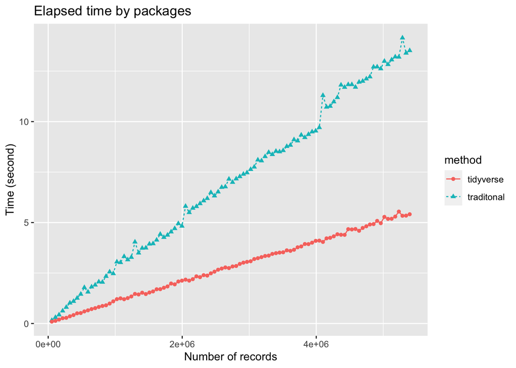

```r
ggplot(data = elapse, aes(x = obs, y = elapsed, group = method, colour = method)) +
  geom_line(aes(linetype = method)) +
  geom_point(aes(shape = method)) +
  ggtitle("Elapsed time by packages") +
  ylab("Time (second)") +
  xlab("Number of records")
```

### tidyverse vs data.table

`tidyverse`에서 데이터를 조작하는 기능은 `dplyr` 패키지가 담당하고 있다. 물론 `dplyr` 패키지의 수행 속도도 data frame을 조작하는 전통적인 방법과 함수보다 빠르다. 그러나, 수행속도만 놓고 보면 `data.table` 패키지가 `dplyr` 패키지보다 빠르다. 그러나 `dplyr` 패키지의 장점은 SQL의 로직을 연상하면서도, 데이터를 seamless하게 처리할 수 있다는 장점으로 `data.table` 패키지에 우위에 있다고 생각한다.

`data.table` 패키지의 `fread()` 함수는 데이터 파일을 읽어들이는 함수로 `readr` 패키지의 `read_*()` 함수보다 수행속도가 빠르다. 그러나 읽어들인 데이터가 `data.table` 객체로 만들어지기 때문에 `data.table` 패키지를 사용할 경우에만 유용하겠다 할 수 있다.

## R Interface to Python

```python
import pandas
import time

elapse_time = [0] * r.n
obs = [0] * r.n
size = [0] * r.n

for i in range(r.n):
  path = "diamond_" + str(i + 1) + ".csv"

  start_time = time.time()
  diamond = pandas.read_csv(path)
  elapse_time[i] = time.time() - start_time
  obs[i] = diamond.shape[0]
  size[i] = sys.getsizeof(diamond) / 1024 ** 2
```

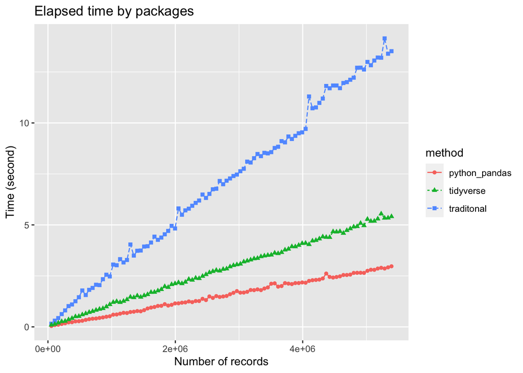

```r
elapse_merge <- data.frame(method = "python_pandas",
                     user = NA, system = NA,
                     elapsed = py$elapse_time, obs = py$obs, size = py$size)

elapse_merge <- rbind(elapse_merge, elapse)

ggplot(data = elapse_merge, aes(x = obs, y = elapsed, group = method, colour = method)) +
  geom_line(aes(linetype = method)) +
  geom_point(aes(shape = method)) +
  ggtitle("Elapsed time by packages") +
  ylab("Time (second)") +
  xlab("Number of records")
```

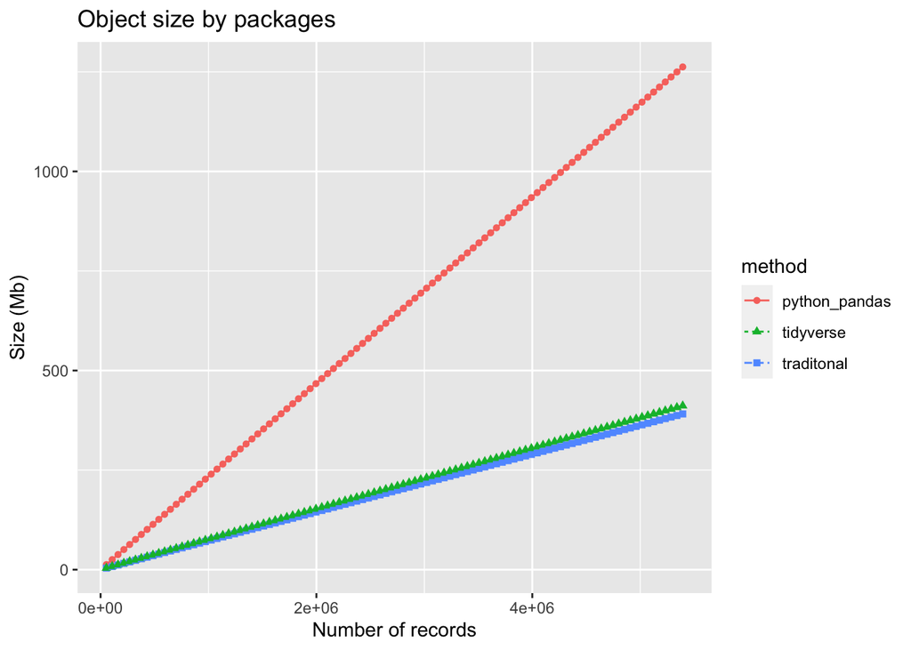

```r
ggplot(data = elapse_merge, aes(x = obs, y = size, group = method, colour = method)) +
  geom_line(aes(linetype = method)) +
  geom_point(aes(shape = method)) +
  ggtitle("Object size by packages") +
  ylab("Size (Mb)") +
  xlab("Number of records")
```

## Invoke a system command

> 참고로, Rtools는 MS-Windows 환경에서 linux를 에뮬레이터 해주는 MinGW(Minimalist GNU for Windows) 기반으로 작동한다.

R에서 `system function call`을 수행하기 위해서 `system()` 함수를 사용한다.

다음은 예제를 위해 생성한 파일들을 삭제하는 `system function call`이다.

```r
# 어떤 shell을 호출하는지 검색
system("ps", intern = TRUE)
```

```
## [1] "  PID TTY           TIME CMD"  "  535 ttys000    0:00.09 -zsh"
```

```r
# 생성한 파일 삭제
system("rm diamond\\_*.csv")
```